# RPointCloud: CLL Clinical Data

Kevin R. Coombes and Jake Reed

# Introduction

We want to illustrate the `RPointCloud` package (Version 0.9.2) with a clinical data set. Not surprisingly, we start by loading the package.

```r
library(RPointCloud)
```

We also load several other useful packages (some of which may eventually get incorporated into the package requirements).

```r
suppressMessages( library(Mercator) )
library(ClassDiscovery)
library(Polychrome)
data(Dark24)
data(Light24)
suppressMessages( library(igraph) )
suppressMessages( library("ape") )
suppressPackageStartupMessages( library(circlize) )
```

Now we fetch the sample clinical data set that is included with the package.

```r
nenv <- new.env()
data("CLL", envir = nenv)
ls(nenv)
```

```
## [1] "clinical"  "daisydist" "ripdiag"
```

```r
attach(nenv)
dim(clinical)
```

```
## [1] 266  29
```

```r
colnames(clinical)
```

```
##  [1] "AgeAtDx"                    "Sex"                        "Race"
##  [4] "mutation.status"            "Light.chain.subtype"        "Zap70Protein"
##  [7] "Rai.Stage"                  "CatRAI"                     "Serum.beta.2.microglobulin"
## [10] "LogB2M"                     "CatB2M"                     "Serum.LDH"
## [13] "LogLDH"                     "White.blood.count"          "LogWBC"
## [16] "CatWBC"                     "CatCD38"                    "Hypogammaglobulinemia"
## [19] "Massive.Splenomegaly"       "Matutes"                    "Hemoglobin"
## [22] "Platelets"                  "Prolymphocytes"             "stat13"
## [25] "stat11"                     "stat12"                     "stat17"
## [28] "Dohner"                     "Purity"
```

The `clinical` object is a numeric matrix containing the clinical data (binary values have been converted to 0-1; categorical values to integers). The `daisydist` is a distance matrix (stored as a `dist` object). Coombes and colleagues [J Biomed Inform. 2021 Jun;118:103788] showed that this is the best way to measure distances between mixed-type clinical data. The `ripdiag` object is a “Rips diagram” produced by applying the `TDA` algorithm to the daisy distances.

# TDA Built-in Visualizations of the Rips Diagram

Here are some plots of the `TDA` results using tools from the original package. (I am not sure what any of these are really good for.)

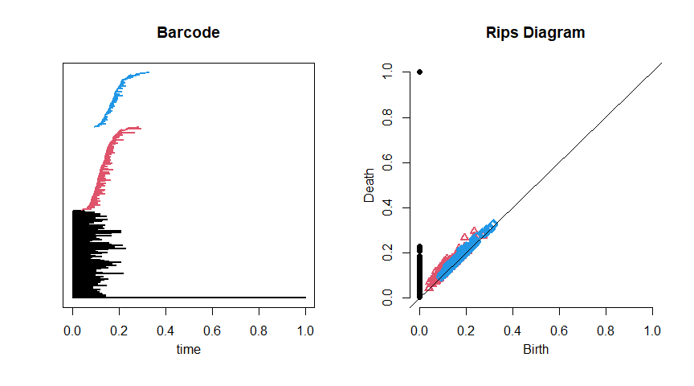

Figure 1 : The Rips barcode diagram from TDA.

```r
diag <- ripdiag[["diagram"]]
opar <- par(mfrow = c(1,2))
plot(diag, barcode = TRUE, main = "Barcode")
plot(diag, main = "Rips Diagram")
```

```r
par(opar)
rm(opar)
```

# Mercator Visualizations of the Underlying Data and Distance Matrix

Now we use our `Mercator` package to view the underlying data.

```r
mercury <- Mercator(daisydist, metric = "daisy", method = "hclust", K = 8)
mercury <- addVisualization(mercury, "mds")
mercury <- addVisualization(mercury, "tsne")
mercury <- addVisualization(mercury, "umap")
mercury <- addVisualization(mercury, "som")
```

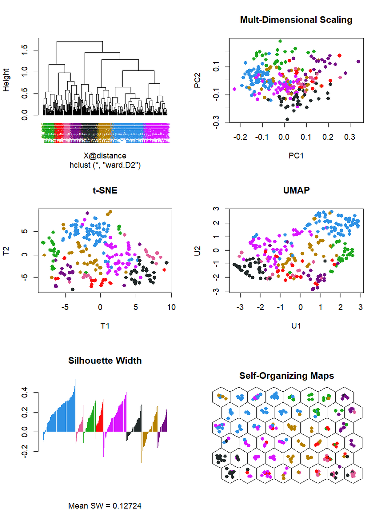

Figure 2 : Mercator Visualizations of the distance matrix.

```r
opar <- par(mfrow = c(3,2), cex = 1.1)
plot(mercury, view = "hclust")
plot(mercury, view = "mds", main = "Mult-Dimensional Scaling")
plot(mercury, view = "tsne", main = "t-SNE")
plot(mercury, view = "umap", main = "UMAP")
barplot(mercury, main = "Silhouette Width")
plot(mercury, view = "som", main = "Self-Organizing Maps")
```

```r
par(opar)
rm(opar)
```

# Dimension Zero

Here is a picture of the “zero-cycle” data, which can also be used ultimately to cluster the points (where each point is a patient). The connected lines are similar to a single-linkage clustering structure, showing when individual points are merged together as the TDA parameter increases.

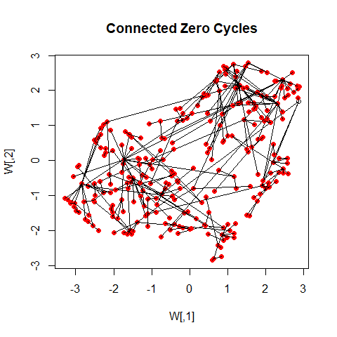

Figure 3 : Hierarchical connections between zero cycles.

```r
nzero <- sum(diag[, "dimension"] == 0)
cycles <- ripdiag[["cycleLocation"]][2:nzero]
W <- mercury@view[["umap"]]$layout
plot(W, main = "Connected Zero Cycles")
for (cyc in cycles) {
  points(W[cyc[1], , drop = FALSE], pch = 16,col = "red")
  X <- c(W[cyc[1], 1], W[cyc[2],1])
  Y <- c(W[cyc[1], 2], W[cyc[2],2])
  lines(X, Y)
}
```

# Using iGraph

We can convert the 0-dimensional cycle structure into a dendrogram, by first passing them through the `igraph` package. We start by putting all the zero-cycle data together, which can be viewed as an “edge-list” from the `igraph` perspective.

```r
edges <- t(do.call(cbind, cycles)) # this creates an "edgelist"
G <- graph_from_edgelist(edges)
G <- set_vertex_attr(G, "label", value = attr(daisydist, "Labels"))
```

Note that we attached the sample names to the graph, obtaining them from the daisy distance matrix. Now we use two different algorithms to decide how to layout the graph.

```r
set.seed(2734)
Lt <- layout_as_tree(G)
L <- layout_with_fr(G)
```

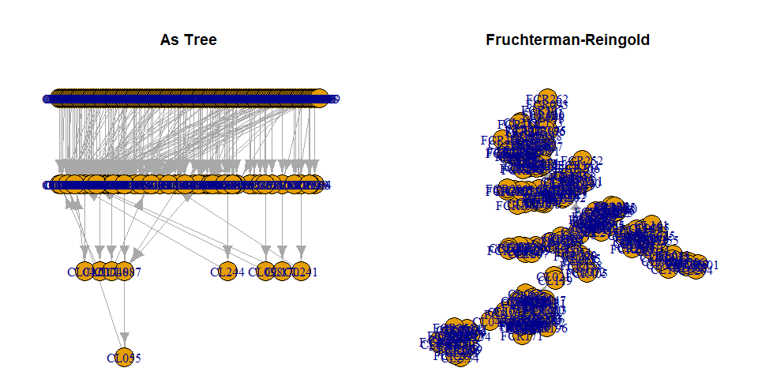

Figure 4 : Two igraph depictions of the zero cycle structure.

```r
opar <- par(mfrow = c(1,2), mai = c(0.01, 0.01, 1.02, 0.01))
plot(G, layout = Lt, main = "As Tree")
plot(G, layout = L, main = "Fruchterman-Reingold")
```

```r
par(opar)
```

Note that the Fruchterman-Reingold layout gives the most informative structure.

## Community Structure

There are a variety of community-finding algorithms that we can apply. (Communities in grpah theory are similar to clusters in other machine learning areas of study.) “Edge-betweenness” seems to work best.

```r
keg <- cluster_edge_betweenness(G) # 20
table(membership(keg))
```

```
##
##  1  2  3  4  5  6  7  8  9 10 11 12 13 14 15 16 17 18 19 20
## 10 21 22 11 21 23  7  8  9  9 20  8 11 26 14 11  8 15  7  5
```

```r
pal <- Dark24[membership(keg)]
```

```r
is.hierarchical(keg)
```

```
## [1] TRUE
```

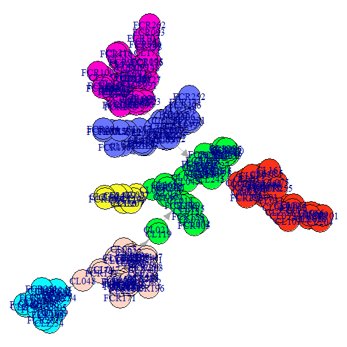

Figure 5 : Community structure, simplified.

```r
H <- as.hclust(keg)
H$labels <- attr(daisydist, "Labels")
K <-  7
colset <- Light24[cutree(H, k=K)]
G2 <- set_vertex_attr(G, "color", value = colset)
e <- 0.01
opar <- par(mai = c(e, e, e, e))
plot(G2, layout = L)
```

```r
par(opar)
```

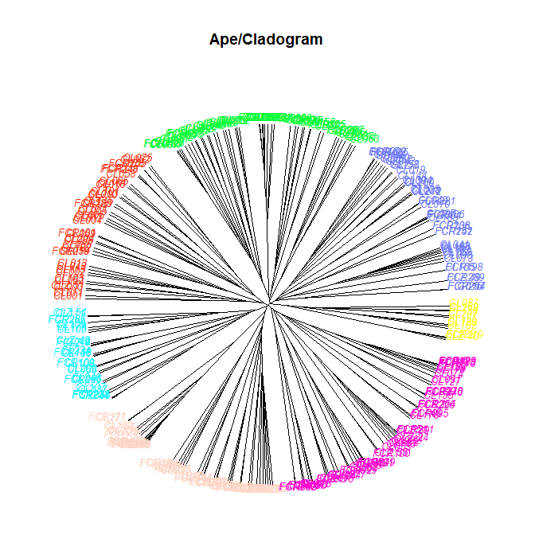

Figure 6 : Cladogram realization, from the ape package.

```r
P <- as.phylo(H)
opar <- par(mai = c(0.01, 0.01, 1.0, 0.01))
plot(P, type = "u", tip.color = colset, cex = 0.8, main = "Ape/Cladogram")
```

```r
par(opar)
rm(opar)
```

## Visualizing Features

In any of the “scatter plot views” (e.g., MDS, UMAP, t-SNE) from Mercator, we may want to overlay different colors to represent different clinical features.

```r
U <- mercury@view[["mds"]]
V <- mercury@view[["tsne"]]$Y
W <- mercury@view[["umap"]]$layout
```

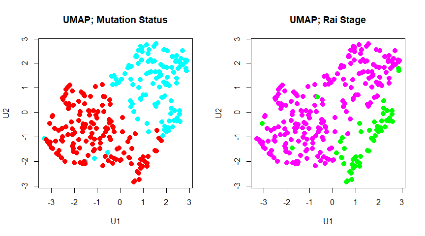

Figure 7 : UMAP visualizations with clinical features.

```r
featMU <- Feature(clinical[,"mutation.status"], "Mutation Status", c("cyan", "red"),
                  c("Mutated", "Unmutated"))
featRai <- Feature(clinical[,"CatRAI"], "Rai Stage", c("green", "magenta"), c("High", "Low"))
opar <- par(mfrow = c(1,2))
plot(W, main = "UMAP; Mutation Status", xlab = "U1", ylab = "U2")
points(featMU, W, pch = 16, cex = 1.4)
plot(W, main = "UMAP; Rai Stage", xlab = "U1", ylab = "U2")
points(featRai, W, pch = 16, cex = 1.4)
```

```r
par(opar)
rm(opar)
```

# Significance

We have a statistical approach to deciding which of the detected cycles are statistically significant. Empirically, the persistence of 0-dimensional cycles looks like a gamma distribution, while the persistence of higher dimensional cycles looks like an exponential distribution. In both cases, we use an empirical Bayes approach, treating the observed distribution as a mixture of either gamma or exponential (as appropriate) with an unknown distribution contributing to heavier tails.

```r
persistence <- diag[, "Death"] - diag[, "Birth"]
```

## Zero-Cycles (Connected Components)

```r
d0 <- persistence[diag[, "dimension"] == 0]
d0 <- d0[d0 < 1]
summary(d0)
```

```
##     Min.  1st Qu.   Median     Mean  3rd Qu.     Max.
## 0.003652 0.054455 0.076682 0.084373 0.108333 0.227561
```

```r
mu <- mean(d0)
nu <- median(d0)
sigma <- sd(d0)
shape <- mu^2/sigma^2
rate <- mu/sigma^2
xx <- seq(0, 0.23, length = 100)
yy <- dgamma(xx, shape = shape, rate = rate)
```

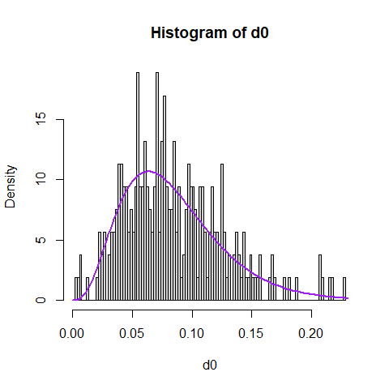

Figure 8 : Histogram of the duration of zero cycles, with an overlaid gammm distibution.

```r
hist(d0, breaks = 123, freq = FALSE)
lines(xx, yy, col = "purple", lwd = 2)
```

## One-Cycles (Loops)

Now we want to determine if there are significant “loops” in the data, and, if so, how many?

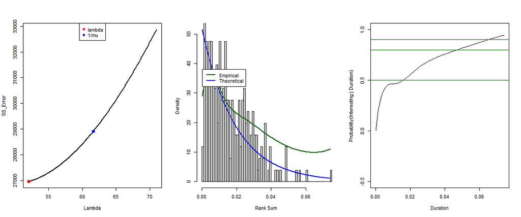

Figure 9 : Empirical Bayes detection of significant one-cycles.

```r
d1 <- persistence[diag[, "dimension"] == 1]
ef <- ExpoFit(d1) # should be close to log(2)/median?
eb <- EBexpo(d1, 200)
opar <- par(mfrow = c(1,3))
plot(ef)
hist(eb)
plot(eb, prior = 0.56)
```

```r
par(opar)
rm(opar)
sum(d1 > cutoffSignificant(eb, 0.8, 0.56)) # posterior 80%, prior 0.56
```

[output not shown]

```r
sum(d1 > 0.065) # post 90%
```

```
## [1] 1
```

```r
which(d1 > 0.047)
```

```
## [1]  50  91  93 123 214 236 249
```

```r
which(d1 > 0.065)
```

```
## [1] 236
```

Let’s pick out the most persistent 1-cycle.

```r
cyc1 <- Cycle(ripdiag, 1, 236, "forestgreen")
cyc1@index
```

```
##       [,1] [,2]
##  [1,]   99  212
##  [2,]    4    7
##  [3,]    2   99
##  [4,]  110  212
##  [5,]   44   59
##  [6,]    4   75
##  [7,]    7   59
##  [8,]   75  110
##  [9,]    2   44
```

Each row represents an edge, by listing the IDs of the points at either end of the line segment. In this case, there are nine edges that link together to form a connected loop (or topological circle).

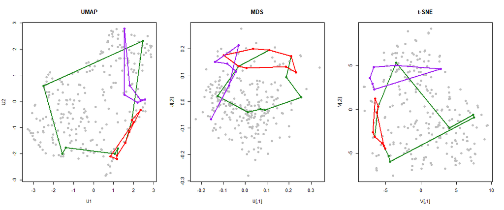

Figure 10 : Three views of three one-cycles.

```r
cyc2 <- Cycle(ripdiag, 1, 123, "red")
cyc3 <- Cycle(ripdiag, 1, 214, "purple")

opar <- par(mfrow = c(1, 3))
plot(cyc1, W, lwd = 2, pch = 16, col = "gray", xlab = "U1", ylab = "U2", main = "UMAP")
lines(cyc2, W, lwd=2)
lines(cyc3, W, lwd=2)

plot(U, pch = 16, col = "gray", main = "MDS")
lines(cyc1, U, lwd = 2)
lines(cyc2, U, lwd = 2)
lines(cyc3, U, lwd = 2)

plot(V, pch = 16, col = "gray", main = "t-SNE")
lines(cyc1, V, lwd = 2)
lines(cyc2, V, lwd = 2)
lines(cyc3, V, lwd = 2)
```

```r
par(opar)
rm(opar)
```

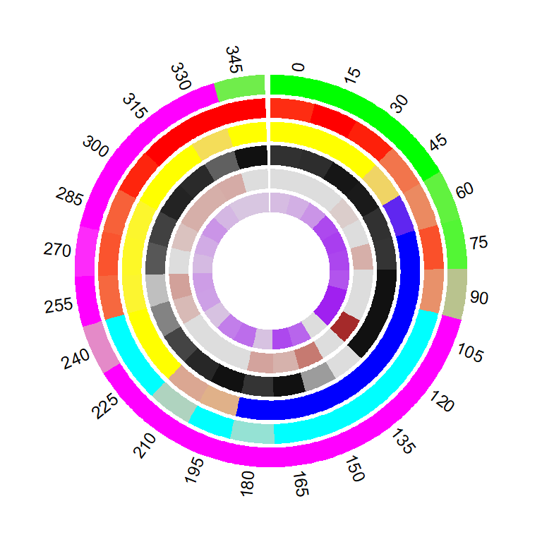

Figure 11 : Circos plot of features varying around the most persistent cycle.

```r
poof <- angleMeans(W, ripdiag, cyc1, clinical)
poof[is.na(poof)] <- 0
angle.df <- poof[, c("mutation.status", "CatB2M", "CatRAI", "CatCD38",
                     "Massive.Splenomegaly", "Hypogammaglobulinemia")]
colorScheme <- list(c(M = "green", U = "magenta"),
                    c(Hi = "cyan", Lo ="red"),
                    c(Hi = "blue", Lo = "yellow"),
                    c(Hi = "#dddddd", Lo = "#111111"),
                    c(No = "#dddddd", Yes = "brown"),
                    c(No = "#dddddd", Yes = "purple"))
annote <- LoopCircos(cyc1, angle.df, colorScheme)
image(annote)
```

## Two-Cycles (Voids)

Now we want to determine if there are significant “voids” (empty interiors of spheres) in the data, and, if so, how many?

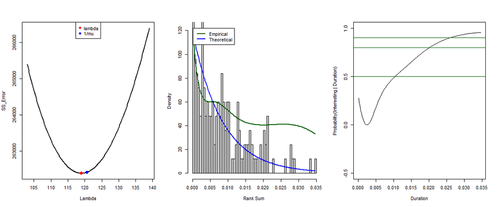

Figure 12 : Empirical Bayes detection of significant two-cycles.

```r
d2 <- persistence[diag[, "dimension"] == 2]
ef <- ExpoFit(d2) # should be close to log(2)/median?
eb <- EBexpo(d2, 200)
opar <- par(mfrow = c(1, 3))
plot(ef)
hist(eb)
plot(eb, prior = 0.75)
```

```r
par(opar)
rm(opar)
sum(d2 > cutoff(0.8, 0.75, eb)) # posterior 80%, prior 0.56
```

```
## [1] 87
```

```r
sum(d2 > cutoff(0.95, 0.75, eb)) # posterior 90%, prior 0.56
```

```
## [1] 82
```

```r
cutoff(0.95, 0.75, eb)
```

```
## $low
## [1] 8.703499e-05
##
## $high
## [1] 0.03263812
```

```r
sum(d2 > 0.032) # post 90%
```

```
## [1] 2
```

```r
which(d2 > 0.034)
```

```
## [1] 95
```

```r
vd <- Cycle(ripdiag, 2, 95, "purple")
mds <- cmdscale(daisydist, k = 3)
voidPlot(vd, mds)
voidFeature(featMU, mds, radius = 0.011) # need to increase radius when you overlay one sphere on another
rgl::rglwidget()
```

[interactive chart not shown]

```r
#htmlwidgets::saveWidget(rglwidget(), "mywidget.html")
```

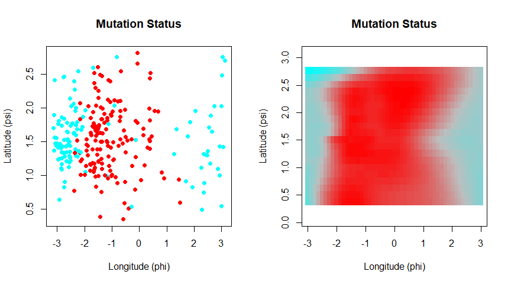

Figure 13 : Planar projection of mutation status around void.

```r
ob <- Projection(vd, mds, featMU, span = 0.2)
opar <- par(mfrow = c(1,2))
plot(ob)
image(ob, col = colorRampPalette(c("cyan", "gray", "red"))(64))
```

```r
par(opar)
rm(opar)
```

```r
options(oopt)
detach("nenv")
rm(nenv)
```